# Credit_card_FE_Python_more_examples-1

## Achieve Model Stability by Aggregating Multiple Models

The solution is to train multiple models then aggregate the scores. By aggregating multiple models, the chance of overfitting is greatly reduced and the prediction accuracy will be improved.

### Method 1: Average

```python
# Combination by average
# The test_scores_norm is 26548 x 14. The "average" function will take the average of the 14 columns. The result "y_by_average" is a single column:
y_by_average = average(test_scores_norm)
# import matplotlib.pyplot as plt
# plt.hist(y_by_average, bins= 100) # arguments are passed to np.histogram
# plt.title("Combination by average")
# plt.show()
```

```
[(-0.5, 1.0), Text(0.5, 1.0, 'Score combination by average')]
```

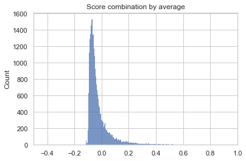

```python
sns.histplot(y_by_average).set(xlim=(-0.5,1), title='Score combination by average')
```

- The graph of average score center on 0, becasue the score is based on the standarized data
- By graph, we can see 0.2 might be a reasonable boundary for abnormal data

```python
#set boundary to get abnormal datat
df_test = pd.DataFrame(X_test)
df_test['y_by_average_score'] = y_by_average
df_test['y_by_average_cluster'] = np.where(df_test['y_by_average_score']<0.2, 0, 1)
df_test['y_by_average_cluster'].value_counts()
```

```
0    25398
1     1150
Name: y_by_average_cluster, dtype: int64
```

```python
df_test.groupby('y_by_average_cluster').mean()
```

| y_by_average_cluster | agency_merchant_avg_ratio_amount | agency_merchant_avg_median_amount | agency_merchant_avg_month_ratio_amount | agency_merchant_median_month_ratio_amount | agency_merchant_total_transaction | cardholder_avg_ratio_amount | cardholder_median_ratio_amount | cardholder_avg_month_ratio_amount | cardholder_median_month_ratio_amount | cardholder_m/y_ratio_transaction | cardholder_w/m_ratio_transaction | cardholder_agency_merchant_avg_ratio_amount | cardholder_agency_merchant_median_ratio_amount | y_by_average_score |
| --- | --- | --- | --- | --- | --- | --- | --- | --- | --- | --- | --- | --- | --- | --- |
| 0 | 0.829182 | 2.008280 | 8.662960e-01 | 8.662960e-01 | 1703.561068 | 0.857289 | 2.401345 | 9.254767e-01 | 2.245309 | 0.114995 | 0.039891 | 5.714447e+09 | 2.089205 | -0.034611 |
| 1 | 4.694523 | 16.914897 | 2.660550e+13 | 2.660550e+13 | 2561.960000 | 4.223780 | 16.428750 | -1.262042e+13 | 15.382500 | 0.338528 | 0.164140 | -4.255280e+14 | 8.470363 | 1.902374 |

- cluster 1 have the score much higher than cluster 0

### Method 2: The Maximum of Maximum (MOM)

- The only different is to get the max score for all features

```python
# Combination by mom
y_by_maximization = maximization(test_scores_norm)
```

```
[(-0.5, 1.0), Text(0.5, 1.0, 'Score combination by max')]
```

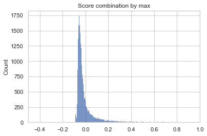

```python
sns.histplot(y_by_maximization).set(xlim=(-0.5,1), title='Score combination by max')
```

- The graph of maximum score center on 0, becasue the score is based on the standarized data
- By graph, we can see 0.19 might be a reasonable boundary for abnormal data

```python
df_test = pd.DataFrame(X_test)
df_test['y_by_maximization_score'] = y_by_maximization
df_test['y_by_maximization_cluster'] = np.where(df_test['y_by_maximization_score']<0.19, 0, 1)
df_test['y_by_maximization_cluster'].value_counts()
```

```
0    25018
1     1530
Name: y_by_maximization_cluster, dtype: int64
```

- About 5.7 percentage of transations are abnoraml

```python
1530/(1530+25018)
```

```
0.05763145999698659
```

- When I use the Maximum-of-Maximum method, I get 1530 data points that have the outlier scores higher than 0.19 .
- I use the following code to produce the summary statistics by cluster.

```python
df_test.groupby('y_by_maximization_cluster').mean()
```

| y_by_maximization_cluster | agency_merchant_avg_ratio_amount | agency_merchant_avg_median_amount | agency_merchant_avg_month_ratio_amount | agency_merchant_median_month_ratio_amount | agency_merchant_total_transaction | cardholder_avg_ratio_amount | cardholder_median_ratio_amount | cardholder_avg_month_ratio_amount | cardholder_median_month_ratio_amount | cardholder_m/y_ratio_transaction | cardholder_w/m_ratio_transaction | cardholder_agency_merchant_avg_ratio_amount | cardholder_agency_merchant_median_ratio_amount | y_by_average_score | y_by_average_cluster | y_by_maximization_score |
| --- | --- | --- | --- | --- | --- | --- | --- | --- | --- | --- | --- | --- | --- | --- | --- | --- |
| 0 | 0.809326 | 1.950901 | 8.493020e-01 | 8.493020e-01 | 1693.826137 | 0.835004 | 2.322252 | 9.103338e-01 | 2.194516 | 0.113263 | 0.038852 | 9.410310e-01 | 2.067067 | -0.037112 | 0.000000 | -0.022128 |
| 1 | 4.257509 | 14.895358 | 2.121798e+13 | 2.121798e+13 | 2557.627601 | 3.930073 | 14.965291 | -1.006483e+13 | 13.606595 | 0.323425 | 0.157078 | -3.392594e+14 | 7.563632 | 1.553680 | 0.797503 | 1.666708 |

- cluster 1 have the score much higher than cluster 0

### Method 3: The Average of Maximum (AOM)

```python
# Combination by aom
y_by_aom = aom(test_scores_norm, 7)
```

```
[(-0.5, 1.0), Text(0.5, 1.0, 'Score combination by Average of Maximum')]
```

[figure not shown]

```python
sns.histplot(y_by_maximization).set(xlim=(-0.5,1), title='Score combination by Average of Maximum')
```

- The graph of average score center on 0, becasue the score is based on the standarized data
- By graph, we can see 0.19 might be a reasonable boundary for abnormal data

```python
df_test = pd.DataFrame(X_test)
df_test['y_by_aom_score'] = y_by_aom
df_test['y_by_aom_cluster'] = np.where(df_test['y_by_aom_score']<0.19, 0, 1)
df_test['y_by_aom_cluster'].value_counts()
```

```
0    25168
1     1380
Name: y_by_aom_cluster, dtype: int64
```

- About 5.2 percentage of transations are abnoraml

```python
1380/(1380+25168)
```

```
0.05198131686002712
```

- When I use the Average-of-Maximum method, I get 1380 data points that have the outlier scores higher than 0.19.
- I use the following code to produce the summary statistics by cluster.

```python
df_test.groupby('y_by_aom_cluster').mean()
```

| y_by_aom_cluster | agency_merchant_avg_ratio_amount | agency_merchant_avg_median_amount | agency_merchant_avg_month_ratio_amount | agency_merchant_median_month_ratio_amount | agency_merchant_total_transaction | cardholder_avg_ratio_amount | cardholder_median_ratio_amount | cardholder_avg_month_ratio_amount | cardholder_median_month_ratio_amount | cardholder_m/y_ratio_transaction | cardholder_w/m_ratio_transaction | cardholder_agency_merchant_avg_ratio_amount | cardholder_agency_merchant_median_ratio_amount | y_by_average_score | y_by_average_cluster | y_by_maximization_score | y_by_maximization_cluster | y_by_aom_score |
| --- | --- | --- | --- | --- | --- | --- | --- | --- | --- | --- | --- | --- | --- | --- | --- | --- | --- | --- |
| 0 | 0.813259 | 1.965385 | 8.522320e-01 | 8.522320e-01 | 1694.609107 | 0.840042 | 2.333277 | 9.142282e-01 | 2.199312 | 0.113645 | 0.039088 | 9.428551e-01 | 2.071685 | -0.036632 | 0.000000 | -0.021551 | 0.00596 | -0.031758 |
| 1 | 4.340700 | 15.212769 | 2.217125e+13 | 2.217125e+13 | 2582.156522 | 3.977252 | 15.332253 | -1.051702e+13 | 14.031844 | 0.325903 | 0.158075 | -3.545015e+14 | 7.726359 | 1.616391 | 0.794203 | 1.732072 | 1.00000 | 1.665417 |

- cluster 1 have the score much higher than cluster 0

### Method 4: The maximum of average (MOA)

```python
# Combination by moa
y_by_moa = moa(test_scores_norm, n_buckets=7)
```

```
[(-0.5, 1.0), Text(0.5, 1.0, 'Score combination by Maximum of Average')]
```

[figure not shown]

```python
sns.histplot(y_by_maximization).set(xlim=(-0.5,1), title='Score combination by Maximum of Average')
```

- The graph of average score center on 0, becasue the score is based on the standarized data
- By graph, we can see 0.19 might be a reasonable boundary for abnormal data

```python
df_test = pd.DataFrame(X_test)
df_test['y_by_moa_score'] = y_by_moa
df_test['y_by_moa_cluster'] = np.where(df_test['y_by_moa_score']<0.19, 0, 1)
df_test['y_by_moa_cluster'].value_counts()
```

```
0    25085
1     1463
Name: y_by_moa_cluster, dtype: int64
```

- About 5.5 percentage of transations are abnoraml

```python
#calculate the percentage of abnoraml data
1463/(25085+1463)
```

```
0.055107729395811364
```

- When I use the Maximum-of-Average method, I get 1463 data points that have the outlier scores higher than 0.19.
- I use the following code to produce the summary statistics by cluster.

```python
df_test.groupby('y_by_moa_cluster').mean()
```

| y_by_moa_cluster | agency_merchant_avg_ratio_amount | agency_merchant_avg_median_amount | agency_merchant_avg_month_ratio_amount | agency_merchant_median_month_ratio_amount | agency_merchant_total_transaction | cardholder_avg_ratio_amount | cardholder_median_ratio_amount | cardholder_avg_month_ratio_amount | cardholder_median_month_ratio_amount | cardholder_m/y_ratio_transaction | cardholder_w/m_ratio_transaction | cardholder_agency_merchant_avg_ratio_amount | cardholder_agency_merchant_median_ratio_amount | y_by_average_score | y_by_average_cluster | y_by_maximization_score | y_by_maximization_cluster | y_by_aom_score | y_by_aom_cluster | y_by_moa_score |
| --- | --- | --- | --- | --- | --- | --- | --- | --- | --- | --- | --- | --- | --- | --- | --- | --- | --- | --- | --- | --- |
| 0 | 0.807018 | 1.945925 | 8.466205e-01 | 8.466205e-01 | 1692.659916 | 0.833417 | 2.313141 | 9.090989e-01 | 2.181436 | 0.113205 | 0.038832 | 9.392901e-01 | 2.062882 | -0.037303 | 0.000000 | -0.022309 | 0.002671 | -0.032474 | 0.000000 | -0.029340 |
| 1 | 4.247591 | 14.794868 | 2.091342e+13 | 2.091342e+13 | 2565.224880 | 3.912853 | 14.940043 | -9.920361e+12 | 13.667055 | 0.321396 | 0.155729 | -3.343897e+14 | 7.556485 | 1.534117 | 0.786056 | 1.645577 | 1.000000 | 1.581395 | 0.943267 | 1.614515 |

- cluster 1 have the score much higher than cluster 0

# Conclusion

#### Analysis why I identify above those credit card transactions as anomalous.

- Use KNNs to get the score of each feature for each credit card transaction
- Draw histgram to show the outliers.
- Outlier boundary is clear to finger out
- Not only use one method, but try to analize Average, Maximum of Maximum (MOM), Average of Maximum (AOM) and Maximum of Average (MOA) for score to prevent overfitting and improve accuracy in detection

#### Business Insight

- Fraud detection systems should be capable of detective work on-line transactions.
- My graph can gives a visusal explanation to the business people
- There are about 5% transactions are abnormal, it is reasonable.